# R Intro für Biotechnologen

U. Rieger

# 1 Laden benötigter Pakete

In diesem Intro werden wir mit dem Paket Biotech arbeiten, dieses installieren wir mit:

```r
# devtools::install_github("https://github.com/Utzi1/Biotech")
devtools::load_all("~/Bachelor/Biotech")
```

Installieren müssen wir es nur ein Mal, danach jedoch müssen wir in jedem Skript, in welchem es zum Einsatz kommt, auf seine Existenz verweisen, wir müssen es “laden”:

```r
library(Biotech)

# Wir laden auch tidverse, dieses Paket enthält eine Menge
# nützlicher Funktionen
library(tidyverse)
```

# 2 Teaser

## 2.1 Rohdatenverarbeitung

Ihr habt im Labor den Bradford-Assay durchgeführt und mit Rinderserumalbumin eine Standardreihe aufgenommen, dazu wurden zu jeder Verdünnung vier technische Replikate angefertigt und deren Absorption gemäß der Vorschrift gemessen. Die Ergebnisse der Messung lauten:

| mes.1 | mes.2 | mes.3 | mes.4 | conc |
| --- | --- | --- | --- | --- |
| 0.031 | 0.04 | 0.009 | 0.007 | 0 |
| 0.092 | 0.103 | 0.077 | 0.084 | 20 |
| 0.191 | 0.201 | 0.166 | 0.166 | 40 |
| 0.278 | 0.279 | 0.205 | 0.205 | 60 |
| 0.332 | 0.348 | 0.25 | 0.353 | 80 |
| 0.363 | 0.36 | 0.397 | 0.371 | 100 |

Diese fassen wir gleich als tibble zusammen:

```r
Std <- tibble(
  mes.1 = c(0.031,  0.092,  0.191,  0.278,  0.332, 0.363),
  mes.2 = c(0.04, 0.103, 0.201, 0.279, 0.348, 0.36),

  mes.3 = c(0.009, 0.077, 0.166, 0.205, 0.25, 0.397),
  mes.4 = c(0.007, 0.084, 0.166, 0.205, 0.353, 0.371),
  )
```

Zusätzlich dazu brauchen wir eine Vector, welcher Information über die Konzentration des BSA in den angesetzten Standards (in $\frac{\mu g}{ml}$) bereithält:

```r
conc <- seq(
            # die geringste Konzentration
            from = 0,
            # die Höchste Konzentration
            to = 100,
            # die Länge
            length.out =
                # diese muss der Anzahl der Messungen entsprechen
                length(Std$mes.1)
            )
```

Die Länge (also Anzahl der einzelnen Werte muss der Anzahl der Standards entsprechen) wird über das Argument length.out gesteuert. Als Nächstes berechnen wir das arithmetische Mittel der technischen Replikate:

```r
Std.mean <- rowMeans(Std)
```

## 2.2 Errechnen eines Linearen Modell

Damit haben wir nun alles um ein lineares Modell vom Typ $y = m \cdot x + b$ zu errechnen und zu plotten, dies geht recht leicht:

```r
# Berechnen des Modells
LinMod(abs = Std.mean, conc = conc) %>%
    # Überführen des Modells in eine schöne Tabelle
  pander::pander()
```

|  | Estimate | Std. Error | t value | Pr(>\|t\|) |
| --- | --- | --- | --- | --- |
| **(Intercept)** | -6.74 | 2.277 | -2.96 | 0.04157 |
| **abs** | 277.5 | 9.547 | 29.06 | 8.345e-06 |

Fitting linear model: conc ~ abs

| Observations | Residual Std. Error | $R^2$ | Adjusted $R^2$ |
| --- | --- | --- | --- |
| 6 | 2.872 | 0.9953 | 0.9941 |

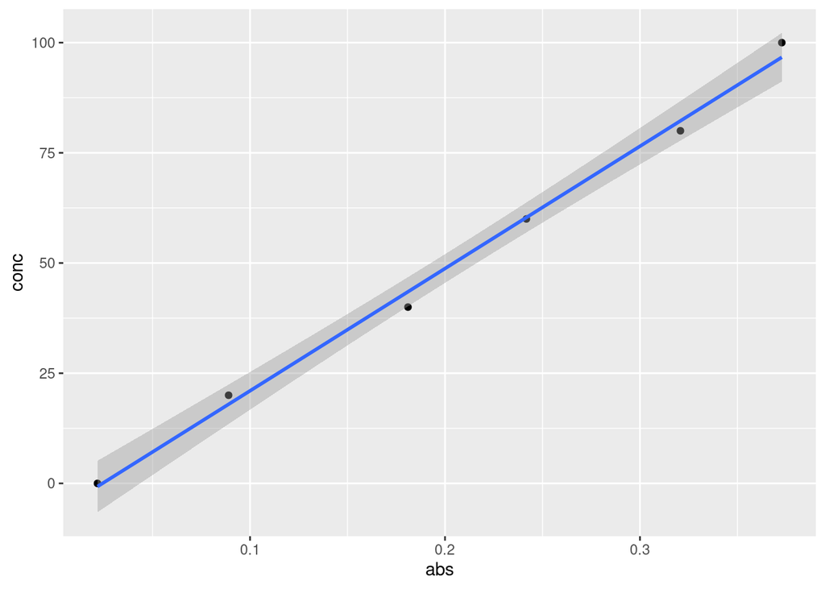

```r
# Plotten des Modells
plot_regression(abs = Std.mean, conc = conc)
```

## 2.3 Konzentrationsbestimmung der Proben

Nach dem selben Verfahren wie die Standardreihe wurde auch mit Proben unbekannter Konzentration verfahren, für diese wurden folgende Absorptionswerte gemessen:

```r
# die gemessenen Werte:
mes.1 <- c(0.185, 0.245, 0.399, 0.429, 0.448, 0.431)

# definieren des Verdünnungsfaktor
FV <- c(80, 80, 40, 40, 20, 20)

# Hieraus berechnen wir dann direkt die Konzentrationen:
conc.mes <-
    conc_eval(abs_P = mes.1, abs_std = Std.mean, conc_std = conc)
```

```
##
## Call:
## stats::lm(formula = conc_std ~ abs_std)
##
## Residuals:
##       1       2       3       4       5       6
##  0.7057  2.0466 -3.4797 -0.3354 -2.2546  3.3175
##
## Coefficients:
##             Estimate Std. Error t value Pr(>|t|)
## (Intercept)   -6.740      2.277   -2.96   0.0416 *
## abs_std      277.459      9.547   29.06 8.35e-06 ***
## ---
## Signif. codes:  0 '***' 0.001 '**' 0.01 '*' 0.05 '.' 0.1 ' ' 1
##
## Residual standard error: 2.872 on 4 degrees of freedom
## Multiple R-squared:  0.9953, Adjusted R-squared:  0.9941
## F-statistic: 844.6 on 1 and 4 DF,  p-value: 8.345e-06
```

```r
conc.rea <-
    conc.mes * FV

# Erzeugen einer Ausgabe
print(conc.rea)
```

```
## [1] 3567.163 4898.968 4158.634 4491.585 2351.227 2256.891
```

Bei genauerer Betrachtung fällt auf, dass die Werte, welche zu den geringeren Verdünnungen gehören viel geringere Konzentrationen aufweisen, als jene der schwachen Verdünnungen. Dies lässt sich damit erklären, dass der Bradford Assay nur innerhalb eines bestimmten linearen Bereichs zuverlässige Ergebnisse liefert. Dieser liegt in der Regel unterhalb einer Konzentration von $120 \frac{\mu g}{ml}$, ein Vergleich der Messwerte mit den theoretischen Konzentrationen ist dabei hilfreich.

# 3 Eine Einführung in R

## 3.1 Skript, Konsole & Interpreter

**Dateiendung**

Das Skript selbst ist eine Textdatei, diese endet mit `.R`, so wie eine Excel-Datei auf `.xsxl` endet. Die Datei mit Namen `irgendwas.R` kann zwar in jedem beliebigen Editor bearbeitet werden, wird aber nur erkannt, wenn die Endung korrekt ist.

**Inhalt**

In der Datei, welche auf `.R`, endet finden wir einen von R interpretierbaren Text. Der Inhalt muss also konform zur R-Language-Definition (R Core Team 2018) sein.

Wenn man dann das Skript geschrieben hat, kann es zum Beispiel über den Kommandozeilen-Interpreter interpretiert werden, bewerkstelligt wird das dann über `source("Pfad/zur/Datei")`. Wenn man sich in einem IDE befindet, wie zum Beispiel R-Studio, erfolgt das Bearbeiten und Interpretieren von Skripten interaktiv.

## 3.2 Grundlegende Begriffe

Die recht gut nachvollziehbare Syntax kann gerade auch fachfremden Anwendern den Beginn enorm erleichtern, bereits ein paar Kenntnisse der englischen Sprache reichen teilweise aus, um viele der Befehle zu verstehen, einige besonders wichtige Zeichen (Operatoren) und Grundfunktionen wollen wir uns jedoch explizit ansehen:

**`+ - * / ̂%% %/%`**

Sind die arithmetischen Operatoren *plus*, *minus*, *mal*, *geteilt*, *hoch*, *Modulus* (Teilen mit Rest) und die *ganzzahlige Division*.

**`<-`**

Ordnet innerhalb einer Umgebung zu, er ist der gebräuchlichste `assignment operator`.

**`< > <= >= == !=`**

Sind relationale Operatoren für *kleiner als*, *größer als*, *kleiner gleich*, *größer gleich*, *exakt gleich* und *ungleich*.

**`& | !`**

Sind logische Operatoren für *und* , *oder* und *nicht*.

**`[] $`**

Sind subsetting-Operatoren.

**`function()`**

Erzeugt eine Funktion.

**`if() else()`**

Sind Bedingungen.

**`for()`**

Erzeugt eine `for`-Schleife.

**`while()`**

Erzeugt eine `while`-Schleife.

**`#`**

Markiert den Beginn eines Kommentars.

Alle gelisteten Begriffe sind *reserviert*, das bedeutet, dass sie zum Beispiel mittels einer Zuordnung durch einen Pfeil nicht überschrieben werden können. Es gibt weitere *Reserved Words in R*, diese können durch `?reserved` ausgegeben werden.

### 3.2.1 Zuweisungen

Ein weiterer reservierter Begriff ist `NA`. Wenn wir versuchen, `NA` mit einer neuen Variable zu überschreiben bekommen wir eine Fehlermeldung:

```
> NA <- 1
Fehler in NA <- 1 : ungültige (do_set) linke Seite in Zuweisung
```

Das Selbe wird auch bei den anderen reservierten Begriffen passieren. Eine Zuweisung kann auch in eine andere Richtung erfolgen:

```
> c(1, 2, 3) -> x
> x
[1] 1 2 3
# das geht nicht:
> y -> c(1, 2, 3)
Fehler: Objekt 'y' nicht gefunden
```

Das 2. Statement hingegen weist schlichtweg in die falsche Richtung.

```
# auch das gleich ist in der Lage eine Zuweisung vorzunehmen
> x = c(1, 2, 3)
# x wird nun auf y übertragen
> x -> y
> y
[1] 1 2 3
# x bleibt bestehen
> x
[1] 1 2 3
# sind die beiden exakt gleich?
> x == y
[1] TRUE TRUE TRUE
# Ja!
```

Es ist empfehlenswert sich, gerade zu Beginn, mit einfachen Operationen ein Bild von der Funktion der Sprache zu machen und die Operatoren zu nutzen, um sie kennen zu lernen.

### 3.2.2 Vektoren und deren Subsetting

Unter Subsetting versteht man das Bilden kleiner Untereinheiten (subsets) aus größeren Sets (Datensets), im einfachsten Fall ein Vektor:

```
> x <- c(1:6)
# Subsets nach Position
> x[2:3]
[1] 2 3
# ein Subset als Zuweisung
> y <- x[1:4]
> y
[1] 1 2 3 4
```

Den Elementen eines Vektors können auch Namen gegeben werden, das geschieht über `names()`:

```
> names(x) = c("eins", "zwei", "drei", "vier", "fünf", "sechs")
> x
 eins  zwei  drei  vier  fünf sechs
    1     2     3     4     5     6
# nun lassen wir uns den Wert zum Namen ausgeben
> x["zwei"]
zwei
   2
# !!ACHTUNG!! der Name wird nur als String erkannt
> x[zwei]
Fehler: Objekt 'zwei' nicht gefunden
# die Namen werden auf neue Objekte übertragen
> y <- x[1:4]
> y
eins zwei drei vier
   1    2    3    4
```

**Namen** = `string`?! Ja, korrekt geraten, der Begriff `string` bedeutet, dass es sich um eine Reihe von Buchstaben handelt. Für eine Reihe von Buchstaben gelten andere Regeln als für `numeric`’s (Zahlen, diese werden auch als `double`) bezeichnet. Grundsätzlich gilt für `strings`, dass sie eben in Anführungszeichen weiter gegeben werden:

[output not shown]

## 3.3 Höhere Datenstrukturen

### 3.3.1 Matrices

Eine Matrix ist primär eine zweidimensionale Anordnung von Werten in Reihen und Spalten. Wenn wir eine solche Matrix entstehen lassen wollen können wir dazu mit einem Vektor starten:

```
> x <- 1:9
# eine Matrix mit 3 Spalten und 3 Reihen
> mat.x = matrix(x, nrow = 3, ncol = 3)
> mat.x
     [,1] [,2] [,3]
[1,]    1    4    7
[2,]    2    5    8
[3,]    3    6    9
# Transponieren der Matrix
> t(mat.x)
     [,1] [,2] [,3]
[1,]    1    2    3
[2,]    4    5    6
[3,]    7    8    9
# Subset, jetzt in zwei Dimensionen
> mat.x[1:2, 2:3]
     [,1] [,2]
[1,]    4    7
[2,]    5    8
# und noch eins
> mat.x[3,3]
[1] 9
```

### 3.3.2 Listen

Der Datentyp `list` ist recht flexibel, er kann salopp gesagt alles enthalten beispielsweise Matrices, Vektoren, Funktionen und mehr:

```
> Liste <- list(
  Funktion = function(x, y){x+y},
  Matrix = matrix(1:9, nrow = 3, ncol = 3),
  Vektor = c(runif(10)),
  )
> Liste
$Funktion
function(x, y){x+y}

$Matrix
     [,1] [,2] [,3]
[1,]    1    4    7
[2,]    2    5    8
[3,]    3    6    9

$Vektor
 [1] 0.63860417 0.25105358 0.64089547 0.49214046 0.48232077 0.30024825
 [7] 0.92896802 0.62018010 0.02472022 0.77797613

# Listen können über das Dollar-Zeichen subsettet werden
> Liste$Funktion
function(x, y){x+y}
# oder über die eckigen Klammern
> Liste[2]
$Matrix
     [,1] [,2] [,3]
[1,]    1    4    7
[2,]    2    5    8
[3,]    3    6    9
```

### 3.3.3 Dataframes

Der Dataframe ist eine Sonderform der Liste, alle in ihm enthaltenen Elemente haben die selbe Länge, er taucht gerade deswegen sehr oft auf. Sowohl das Subsetting, welches wir bei den Listen kennen gelernt haben, als auch das Subsetting, welches bei Matrices angewandt wird, kann auch auf den Typ Dataframe angewandt werden.

## 3.4 Tibble

Der `tibble` wird auf der offiziellen Website `https://tibble.tidyverse.org/index.html` wie folgt beschrieben:

A `tibble`, or tbl_df, is a modern reimagining of the data.frame, keeping what time has proven to be effective, and throwing out what is not. Tibbles are data.frames that are lazy and surly: they do less (…) and complain more (…).  
(Kirill Müller 2020)

Der `tibble` kann also als moderne Überarbeitung des `data.frame` verstanden werden. Diese Modernisierung beinhaltete vor allem das faul machen der Datenstruktur, welche dazu führt, dass sie öfter Fehler aufwirft. Der `tibble` ist eine sehr gebräuchliche Datenstruktur im `tidyverse` (Wickham et al. 2019), eine moderne Paketsammlung, welcher später noch mehr Aufmerksamkeit geschenkt wird. Die Regeln für das Subsetting bei `tibble`’s sind die selben wie beim `data.frame`. Um einen `tibble` aus, zum Beispiel, Messwerten enstehen zu lassen, gilt:

```
> tibble(
+ Namen = c("Gustav", "Anna", "Roman", "Veronika"),
+ Alter = c(55, 17, 26, 19))
# A tibble: 4 x 2
  Namen    Alter
  <chr>    <dbl>
1 Gustav      55
2 Anna        17
3 Roman       26
4 Veronika    19
```

## 3.5 Datenimport

```
tab.1 <- read_csv("bsp.csv")
Parsed with column specification:
cols(
  V1 = col_double(),
  V2 = col_double(),
  V3 = col_double()
)
> tab.1
# A tibble: 3 x 3
     V1    V2    V3
  <dbl> <dbl> <dbl>
1     1     4     7
2     2     5     8
3     3     6     9
# umkonvertieren in eine Matrix
> mat <- as.matrix(tab.1)
> mat
     V1 V2 V3
[1,]  1  4  7
[2,]  2  5  8
[3,]  3  6  9
# Dimenstionsnamen einführen
> dimnames(mat) <- list( c("x", "y", "z"), c("a", "b", "c"))
> mat
  a b c
x 1 4 7
y 2 5 8
z 3 6 9
```

Für das Einlesen von xslx-Datensätzen steht das Paket `readxl` zur Verfügung, die dort implementierten Funktionen importieren nach einem ähnlichen Schema wie `read_csv` Excel-Datensätze. Unter Verwendung von R-Studio wird der Datenimport stark vereinfacht, da dort ein GUI den Datenimport begleitet.

## 3.6 Funktionen und Kontrollstrukturen

### 3.6.1 `if`

`if` untersucht eine Aussage und abhängig vom Ergebnis der Aussage erzeugt `if` dann eine Ausgabe, ähnlich wie in Aschenputtel beim Linsen sortieren zu ihren Täubchen:

…die schlechten ins Kröpfchen, die guten ins Töpfchen.  
(Grimm and Grimm 2008)

Das hierbei beschriebene Problem könnte in R so gelöst werden:

```
> x = "schlecht"
> if (x == "gut") {
+   print("ab ins Töpfchen")
+ } else if (x == "schlecht") {
+   print("ab ins Kröpfchen")
+ }
[1] "ab ins Kröpfchen"
```

### 3.6.2 `function`

Das `function`-Statement kann Aschenputtel das Leben zusätzlich leichter machen, wenn sie Tippfaul ist, kann sie es in einer Funktion verpacken, welche immer wieder aufgerufen werden kann. Es ist wichtig zu bedenken, dass später von der Funktion nur der Name sichtbar ist und aus diesem Grund ein sinnvoller Name wärmstens zu empfehlen ist. Die Definition einer Funktion erfolgt immer nach dem selben Schema:

```
> Name <- function(Argumente){Funktion (body)}
# oder:
> Add <- function(a, b) a + b
> Add(1, 2)
[1] 3
```

Im 2. Fall kann auf die geschweifte Klammer verzichtet werden, da die ganze Definition auf einer Zeile Platz hat und der Sinn durchaus erhalten bleibt. Für Aschenputtel könnten wir annehmen:

```
> Taube <- function(Linse) {
+         if (Linse == "gut") {
+           print("ab ins Töpfchen")
+         } else if (Linse == "schlecht") {
+           print("ab ins Kröpfchen")
+         }
+ }
> x = "schlecht"
> Taube(x)
[1] "ab ins Kröpfchen"
> y = "gut"
> Taube(y)
[1] "ab ins Töpfchen"
```

### 3.6.3 `for`

Das `for`-Statement ermöglicht es, für mehrere Werte wiederholend die selbe Aufgabe durchzuführen, denn Aschenputtel hat ja nicht nur eine Linse, sondern eine ganze Menge. Hierbei soll aber darauf verwiesen werden, dass der Gebrauch von Schleifen in R eher untypisch ist, da eine Vielzahl von Funktionen zur Verfügung steht welche, sie leicht ersetzen können. Dennoch macht es Sinn sich diese Technik anzueignen. Wenn man sie beherrscht, hann kann man sie häufig sinnvoll einsetzen. Eine weitere wichtige Information zum Gebrauch von `for`-Loops bezieht sich auf ihre Ausgabe. Der `for`-Loop ist langsam, wenn seine Ausgabe nicht zuvor definiert wurde. Das bedeutet im Umkehrschluss, dass man sich über die Ausgabe Gedanken machen sollte. Für Aschenputtel wollen wir nun die `Taube` automatisieren, damit sie in der Lage ist, einen Vektor aus `Linsen` zu klassifizieren und diese entweder ins `Kröpfchen` oder `Töpfchen` zu werfen:

```
1> y <- c("gut", "schlecht", "schlecht", "gut", "gut")
2> Ausgabe <- vector(mode = "list", length = length(y))
3> for (i in y) {
4>    Ausgabe[[i]] <- Taube(i)
4>}
[1] "Ab ins Töpfchen"
[1] "Ab ins Kröpfchen"
# und so weiter
```

1. Zu Beginn erstellen wir den Vektor aus `Linsen` welche dann eben `schlecht` oder `gut` sind
2. Der Vektor `y` aus `Linsen` bestimmt die Länge `length` der Ausgabe da entsprechend der Anzahl an Linsen auch Klassifizierungen vorgenommen werden.
3. Nun wird in `for` jedes Element `i` (also jede `Linse`) in `y` untersucht.
4. Hier wird definiert, womit untersucht wird, nämlich mit `Taube`.

### 3.6.4 `while`

Die `while`-Schleife führt so lange eine Anweisung aus, bis eine Bedingung erfüllt ist, dabei gilt:

```
while(Bedingung){Anweisung}
```

Diese Bedingung kann Aschenputtel zum Beispiel dabei helfen, so lange Linsen zu sortieren, bis sie quantitativ genug davon hat, um mit diesen einen Eintopf zu kochen. Wir können schreiben:

```
1> x = 20
2> Linsen = 100
3> while( x != Linsen ){
4+     print("Esst mehr Linsen")
5+     x = x + 20
6+     print(x)
 + }
[1] "Esst mehr Linsen"
[1] 40
 usw
[1] "Esst mehr Linsen"
[1] 100
```

## 3.7 Pakete und das `tidyverse`

Wie bereits angesprochen verwendet man in R Pakete als Erweiterung des Funktions-Repertoires. Diese Erweiterung erfolgt abhängig von den Ansprüchen des Anwenders und muss dementsprechend vom Anwender individuell angepasst werden. Eine sehr populäre Paketesammlung, das `tidyverse`, soll jedoch nicht unbeachtet bleiben. Unter einer Paketsammlung versteht man den Zusammenschluss mehrerer Pakete zu einem neuen und größerem Paket. Im Fall des `tidyverse` ist diese Sammlung auf das *saubere* Verarbeiten von Daten ausgelegt, der Fokus liegt auf einer verständlichen Syntax und einem anwenderfreundlichen *Code*. Das `tidyverse` beinhaltet folgende Kern-Komponenten (Wickham 2020):

**`ggplot2`**

Im Namen versteckt sich bereits ein Hinweis auf das Buch *The Grammar of Graphics* von Leland Wilkinson (Wilkinson 2005). Auf Basis dieses Buchs werden in `ggplot2` die Weichen für eine verbesserte Datenvisualisierung gelegt.

**`dplyr`**

Das Paket `dplyr` enthält eine Vielzahl verschiedener Funktionen zur Datenmanipulation.

**`readr`**

Das Paket `readr` enthält Funktionen zum Import von Datensätzen.

**`tidyr`**

Das Paket `tidyr` hilft bei der Ordnung von Daten.

**`tibble`**

**`purr`**

Das Paket `purr` ermöglicht weitere Schritte in Richtung funktionales Programmieren.

**`stringr`**

Der Name verrät es bereits: es geht um `string`’s, um das Programmieren mit diesen zu vereinfachen, wird dieses Paket zur Verfügung gestellt.

**`forcats`**

Das Paket `forcats` stellt Tools zur Arbeit mit `factor`’s zur Verfügung.

Die Pakete `ggplot2` und `dplyr` finden in `Biotech` viel Anwendung, dazu später mehr.

## 3.8 Einfache Übungen

Zu Beginn sollte man sich auf den Gebrauch simpler Operatoren konzentrieren, wenn man sie verstanden hat, wird’s später leichter ;-)

```r
x = 1
y = 2

x != y
```

```
## [1] TRUE
```

```r
x == y
```

```
## [1] FALSE
```

```r
x < y
```

```
## [1] TRUE
```

```r
x > y
```

```
## [1] FALSE
```

```r
z = 1
x >= z
```

```
## [1] TRUE
```

```r
x <= z
```

```
## [1] TRUE
```

```r
vec1 <- trunc(runif(n = 10, min = 3, max = 7))
vec2 <- trunc(runif(n = 10, min = 3.5, max = 7.7))
vec3 <- trunc(runif(n = 10, min = 3, max = 8))
inf1 <- c(vec1 == vec2)
inf2 <- c(vec2 == vec3)
inf3 <- c(vec1 == vec3)
inf1 &  inf2
```

```
##  [1] FALSE FALSE FALSE FALSE FALSE FALSE  TRUE FALSE FALSE FALSE
```

```r
inf1 && inf2
```

```
## [1] FALSE
```

```r
inf1 |  inf2
```

```
##  [1] FALSE FALSE  TRUE  TRUE FALSE FALSE  TRUE  TRUE FALSE  TRUE
```

```r
inf1 || inf2
```

```
## [1] FALSE
```

Des weiteren stehen uns eine Menge mathematische Grundfunktionen zur Verfügung, diese sollen an dieser Stelle nur stiefmütterlich behandelt werden:

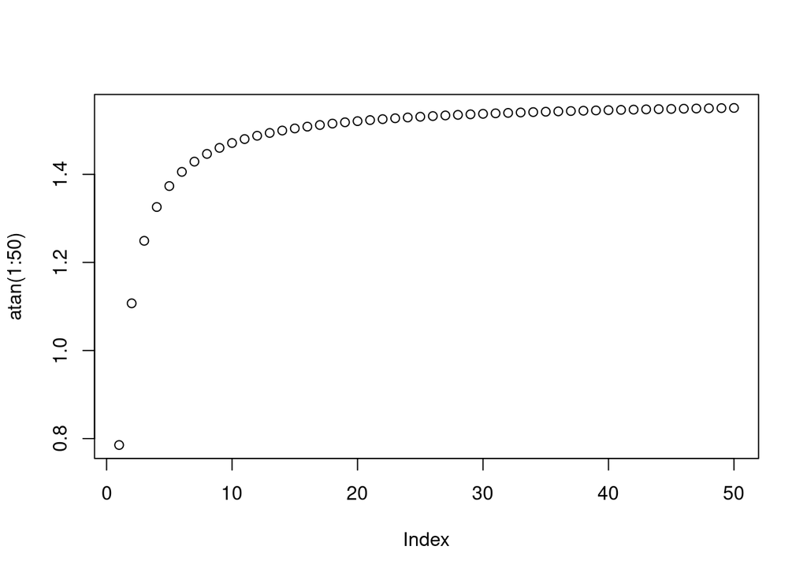

```r
# Ihr könnt die trigonometrischen Funktionen nutzen:
par(mfrow = c(1,1))
plot(atan(1:50))
```

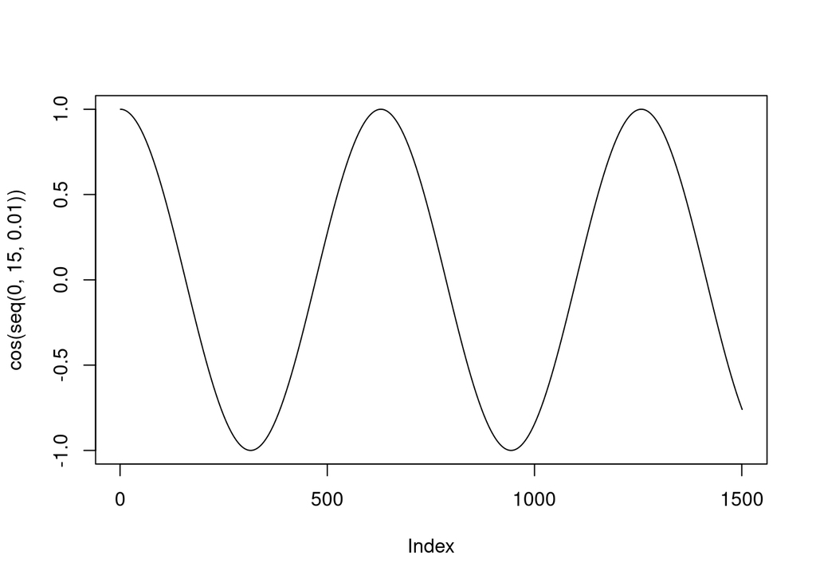

```r
plot(cos(seq(0, 15, .01)), type = "l")
```

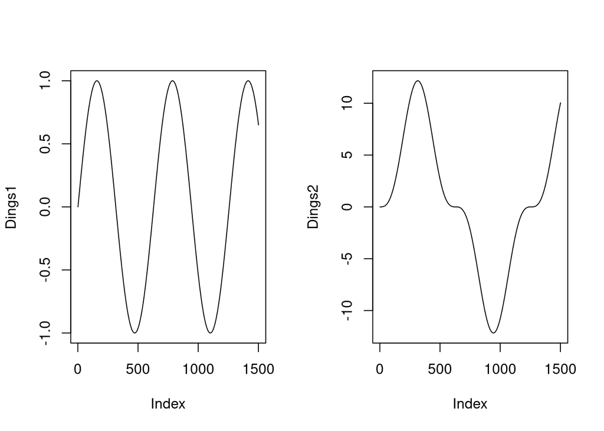

```r
# Man kann toll spielen
Dings1 <- sin(seq(0, 15, .01))
Dings2 <- (sin(seq(0, 15, .01) * .5) * 2.3 )^ 3

# base::par ermöglicht es uns 2 oder mehrere Plots neben einander
# in der selben Grafik unterzubringen
par(mfrow=c(1,2))
plot(Dings1, type = "l")
plot(Dings2, type = "l")
```